# Predicting Ten-Year Coronary Heart Disease Risk: A Statistical Analysis of the Framingham Heart Study Data

Boning Liu

10-23-2024

# 1 Introduction

The objective of this project is to predict the ten-year risk of coronary heart disease (CHD) among participants using data from the Framingham Heart Study. Cardiovascular disease is a leading cause of morbidity and mortality globally, and early identification of individuals at risk is crucial for preventive measures. By leveraging statistical models, this analysis aims to identify key predictors and improve the accuracy of risk predictions, which can contribute to better health outcomes.

The dataset used for this analysis is a subset of the Framingham Heart Study, containing 4,240 observations and 16 variables. These variables include both numerical (e.g., age, BMI, glucose) and categorical (e.g., smoking status, education level, diabetes) features. The data captures demographic information, medical history, and lifestyle factors relevant to heart disease risk. The goal is to explore these variables and determine how they contribute to predicting CHD.

The key questions addressed in this analysis are:

**What are the primary factors that influence the ten-year risk of CHD?** We will use **linear regression** to explore relationships between risk factors and continuous outcomes, such as cholesterol levels or blood pressure.

**Can we accurately predict whether an individual will develop CHD within ten years?** This will be addressed using **logistic regression** to model the probability of experiencing a CHD event within the specified timeframe.

## 1.1 Data Set

The dataset is derived from the Framingham Heart Study, a long-term, ongoing cardiovascular study that began in 1948 in Framingham, Massachusetts. This specific dataset is a subset intended for educational and research purposes.

## 1.2 Data Collection Method:

This subset contains observational data collected during a single medical examination period of the Framingham Heart Study. Each observation represents a participant’s demographic, lifestyle, and health-related information at that point in time.

## 1.3 Number of Variables and Data Types:

Total Observations: 4,240 Number of Variables: 16

Variable Types:

- 8 Categorical Variables: male, education, currentSmoker, BPMeds, prevalentStroke, prevalentHyp, diabetes, TenYearCHD
- 8 Numerical Variables: age, cigsPerDay, totChol, sysBP, diaBP, BMI, heartRate, glucose

## 1.4 Variable Names and Definitions:

1. **male**: Binary indicator of gender (1 = Male, 0 = Female) (**categorical**)
2. **age**: Age at the time of medical examination in years (**numerical**)
3. **education**: Education level of the participant, coded as 1 (Some high school), 2 (High school/GED), 3 (Some college/vocational school), 4 (College) (**categorical**)
4. **currentSmoker**: Indicator of current cigarette smoking status (1 = Smoker, 0 = Non-smoker) (**categorical**)
5. **cigsPerDay**: Number of cigarettes smoked per day by current smokers (**numerical**)
6. **BPMeds**: Use of anti-hypertensive medication at the time of exam (1 = Yes, 0 = No) (**categorical**)
7. **prevalentStroke**: Indicator of a previous stroke (1 = Yes, 0 = No) (**categorical**)
8. **prevalentHyp**: Indicator of prevalent hypertension (1 = Yes, 0 = No) (**categorical**)
9. **diabetes**: Indicator of diabetic status according to examination criteria (1 = Diabetic, 0 = Non-diabetic) (**categorical**)
10. **totChol**: Total cholesterol level measured in mg/dL (**numerical**)
11. **sysBP**: Systolic blood pressure measured in mmHg (**numerical**)
12. **diaBP**: Diastolic blood pressure measured in mmHg (**numerical**)
13. **BM**I: Body Mass Index, calculated as weight (kg)/height (m)^2 (**numerical**)
14. **heartRate**: Heart rate measured in beats per minute (**numerical**)
15. **glucose**: Blood glucose level measured in mg/dL (**numerical**)
16. **TenYearCHD** (response variable): Ten-year risk of coronary heart disease (1 = CHD event within 10 years, 0 = No event) (**categorical**)

# 2 Methodology

This project involves building predictive models to address key questions related to the ten-year risk of coronary heart disease (CHD) in participants from the Framingham Heart Study. We will employ both linear regression and logistic regression to explore relationships between variables and predict outcomes. The following sections outline the methods used and the assumptions underlying each model.

**1. Linear Regression**

Assumptions of linear regression include:

Linearity: The relationship between predictors and the response is linear.

Independence: Observations are independent of each other.

Homoscedasticity: The variance of residuals is constant across all levels of predictors.

Normality of Residuals: Residuals are normally distributed.

**2. Logistic Regression**

Logistic regression will be used to predict the probability of experiencing a CHD event within ten years. This model is appropriate for our binary response variable (TenYearCHD). We will develop multiple candidate models and use metrics like ROC curve and AUC to evaluate their performance, selecting the best model for prediction.

Assumptions of logistic regression include:

Binary Outcome: The response variable is binary.

Linearity in Log-Odds: There is a linear relationship between continuous predictors and the log-odds of the outcome.

Independence of Observations: Observations should be independent of each other.

**3. Cross-Validation and Model Selection**

For both linear and logistic regression, cross-validation will be employed to ensure the generalizability of the models. For linear regression, we will use Mean Squared Error (MSE) as the evaluation metric, while for logistic regression, we will use ROC curve and AUC to determine the best model. Cross-validation helps prevent overfitting and ensures that our models perform well on unseen data.

4. Feature Engineering and Selection

Based on the exploratory data analysis (EDA) conducted, feature engineering will be used to create new variables that may improve model performance. Highly correlated features will be identified and possibly removed to avoid multicollinearity, which can negatively impact model stability and interpretation.

This methodological approach ensures a comprehensive analysis of the factors contributing to CHD risk, leveraging both linear and logistic regression to answer the research questions effectively.

# 3 EDA and Feature Engineering

## 3.1 Handling Missing Value

```r
# Load the data and give it a creative name
HeartHealth <- read.csv("C:/Users/brian/OneDrive/Desktop/WCU GRAD SCHOOL/Fall 2024/STA 551/STA 551/FraminghamHeartStudy.csv")

# Check for missing values in each column
missing_summary <- colSums(is.na(HeartHealth))
print(missing_summary)
```

```
           male             age       education   currentSmoker      cigsPerDay
              0               0             105               0              29
         BPMeds prevalentStroke    prevalentHyp        diabetes         totChol
             53               0               0               0              50
          sysBP           diaBP             BMI       heartRate         glucose
              0               0              19               1             388
     TenYearCHD
              0
```

```r
# Remove rows with any NA values
HeartHealth_clean <- na.omit(HeartHealth)

# Confirm that there are no more missing values
any(is.na(HeartHealth_clean))
```

```
[1] FALSE
```

## 3.2 Distribution of Education

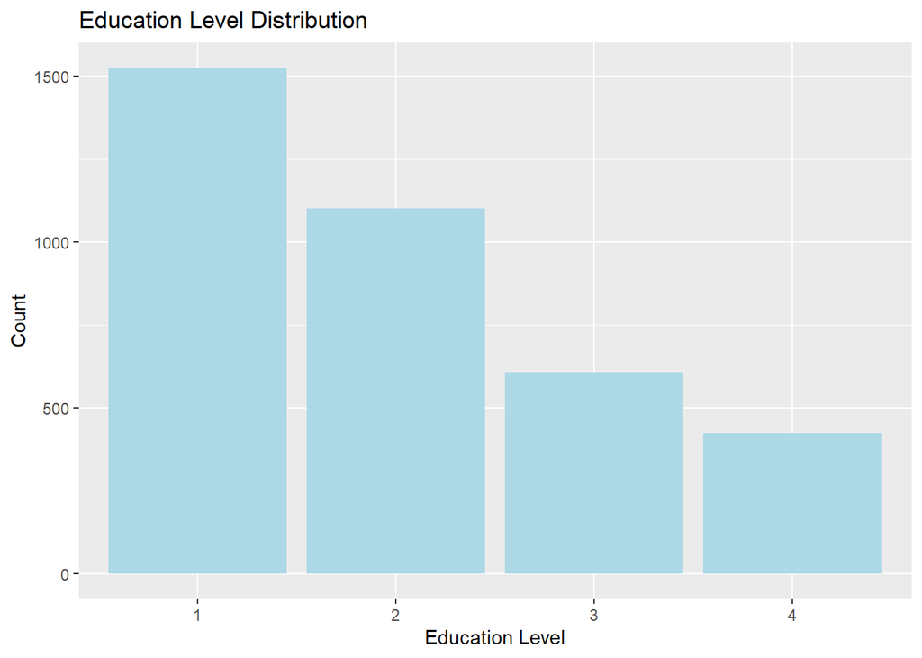

```r
ggplot(HeartHealth_clean, aes(x = factor(education))) +
  geom_bar(fill = "lightblue") +
  labs(title = "Education Level Distribution", x = "Education Level", y = "Count")
```

The bar plot displays the distribution of participants’ education levels in the Framingham Heart Study dataset. The education levels are categorized as follows:

- 1: Some high school
- 2: High school/GED
- 3: Some college/vocational school
- 4: College

From the plot, it is evident that:

- Education Level 1 (Some high school) is the most common, with over 1,500 participants.
- Education Level 2 (High school/GED) is the next most frequent, with just over 1,000 participants.
- Education Levels 3 and 4 (Some college/vocational school and College) have relatively fewer participants, with Education Level 4 being the least represented.

Implications for **Feature Engineering**: The imbalance in education levels may imply potential bias when using education as a predictive feature. To mitigate this, consider grouping education levels (e.g., combining Levels 3 and 4) to create a binary feature: “High Education” vs. “Low Education”.

## 3.3 Distribution of Current Smokers

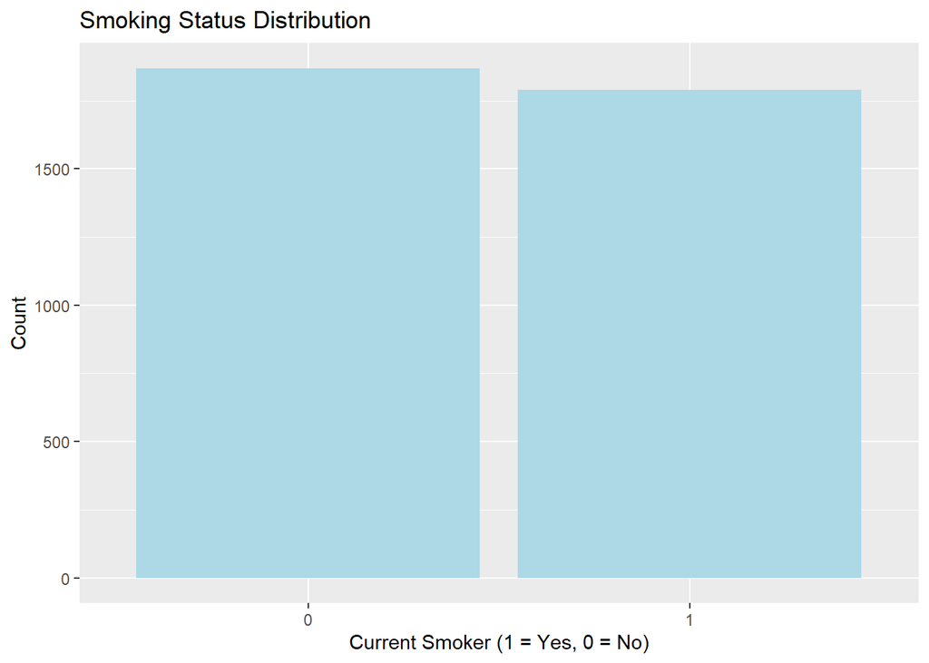

```r
ggplot(HeartHealth_clean, aes(x = factor(currentSmoker))) +
  geom_bar(fill = "lightblue") +
  labs(title = "Smoking Status Distribution", x = "Current Smoker (1 = Yes, 0 = No)", y = "Count")
```

The bar plot shows the distribution of smoking status among participants in the Framingham Heart Study dataset. The variable **currentSmoker** is a binary indicator:

- 0: Non-smoker
- 1: Current smoker

Implications for Feature Engineering:

- Since the smoking status is fairly balanced, this variable can be directly used in modeling without significant concerns regarding data imbalance.
- Potential Interactions:
  - Age and Smoking Status: Create an interaction feature between **age** and **currentSmoker** to understand if smoking is more impactful for specific age groups.
  - Smoking and Blood Pressure: Considering that smoking affects cardiovascular health, an interaction between **currentSmoker** and **sysBP** (systolic blood pressure) or **diaBP** (diastolic blood pressure) could capture a more nuanced relationship.

## 3.4 Distribution of Prevalent Hypertension

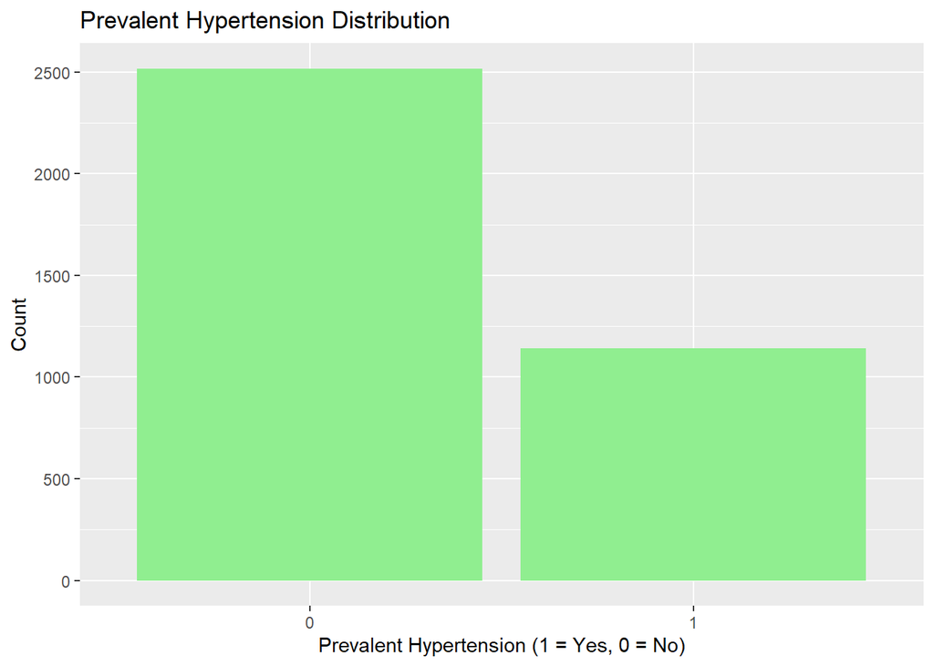

```r
ggplot(HeartHealth_clean, aes(x = factor(prevalentHyp))) +
  geom_bar(fill = "lightgreen") +
  labs(title = "Prevalent Hypertension Distribution", x = "Prevalent Hypertension (1 = Yes, 0 = No)", y = "Count")
```

The bar plot displays the distribution of prevalent hypertension among participants in the Framingham Heart Study dataset. The variable **prevalentHyp** is a binary indicator:

- 0: Participant does not have hypertension.
- 1: Participant has hypertension.

From the plot:

The majority of participants (approximately 2,500) do not have hypertension (0), while a smaller group (approximately 1,200) has hypertension (1). This indicates that hypertension is less common among the participants, with roughly two-thirds of participants being non-hypertensive.

Implications for Feature Engineering:

- Imbalanced Distribution: The distribution shows some imbalance between participants with and without hypertension. This should be kept in mind when using this variable in a predictive model, as it might require weighting or resampling techniques.

## 3.5 Distribution of Diabetes Status

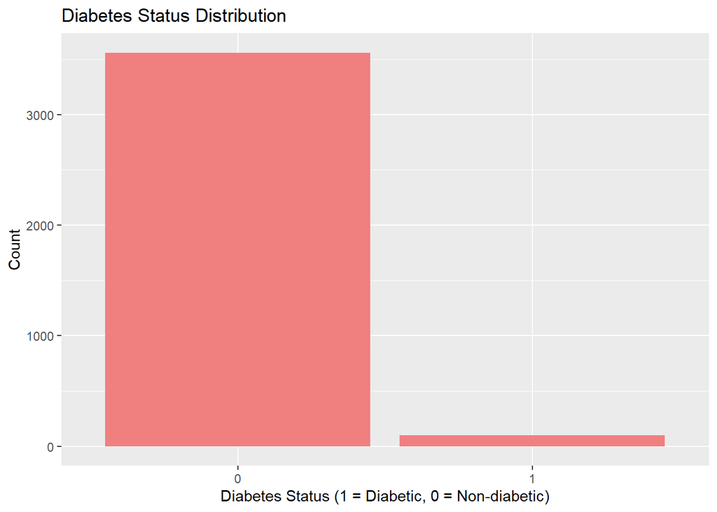

```r
ggplot(HeartHealth_clean, aes(x = factor(diabetes))) +
  geom_bar(fill = "lightcoral") +
  labs(title = "Diabetes Status Distribution", x = "Diabetes Status (1 = Diabetic, 0 = Non-diabetic)", y = "Count")
```

The bar plot displays the distribution of diabetes status among participants in the Framingham Heart Study dataset. The variable **diabetes** is a binary indicator:

- 0: Non-diabetic
- 1: Diabetic

From the plot:

Non-diabetic participants (0) make up the vast majority of the dataset, with over 3,000 individuals. Diabetic participants (1) are very few in number, indicating a high imbalance between the two groups. This suggests that only a small proportion of the participants were diabetic at the time of examination.

Implications for Feature Engineering:

- Severe Class Imbalance: The highly imbalanced distribution of diabetic vs. non-diabetic participants should be taken into account when modeling.

## 3.6 Distribution of Ten Year CHD risk

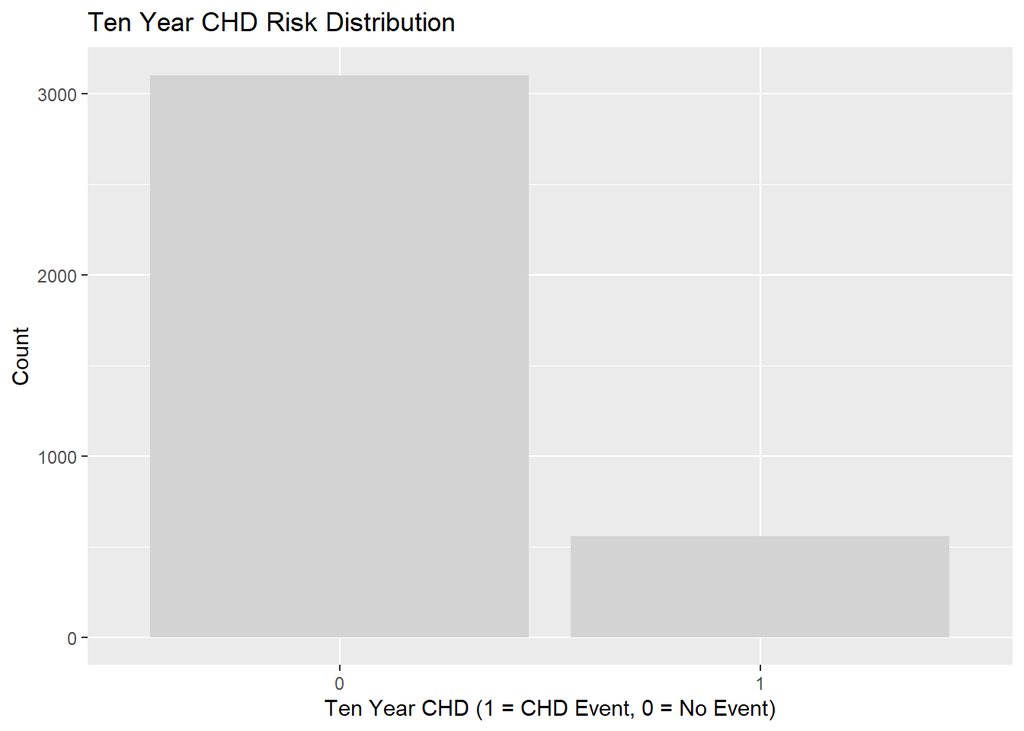

```r
ggplot(HeartHealth_clean, aes(x = factor(TenYearCHD))) +
  geom_bar(fill = "lightgray") +
  labs(title = "Ten Year CHD Risk Distribution", x = "Ten Year CHD (1 = CHD Event, 0 = No Event)", y = "Count")
```

The bar plot shows the distribution of participants with respect to the 10-year risk of coronary heart disease (CHD). The variable **TenYearCHD** is a binary outcome:

- 0: No coronary heart disease event within 10 years.
- 1: Coronary heart disease event within 10 years.

From the plot:

- Most participants (0) did not experience a CHD event within 10 years, with over 3,000 individuals in this category.
- A smaller number of participants (1) experienced a CHD event, which indicates that the dataset has an imbalance between the two classes. This means that most people in the study did not develop CHD.

Implications for Feature Engineering:

- Imbalanced Outcome Variable: Since the response variable (TenYearCHD) is imbalanced, it may affect predictive modeling.

# 4 Linear Regression Modeling

In this section, we aim to build and evaluate linear regression models to understand the relationships between key predictors and continuous response variables related to cardiovascular health, such as systolic blood pressure (sysBP) and cholesterol levels.

## 4.1 Create Candidate Models

We will develop several candidate models to identify the best predictors for cardiovascular outcomes. Initially, we will start with a **simple linear regression model** including a single predictor (e.g., age). We will then expand to **multiple linear regression** models by adding more predictors (e.g., BMI, smoking status, diabetes) to determine if they significantly improve model performance.

Candidate models include:

- **Model 1**: Simple linear regression with **age** as the predictor for **sysBP**.
- **Model 2**: Multiple linear regression including **age**, **BMI**, and **currentSmoker** to predict **sysBP**.
- **Model 3**: A more comprehensive model incorporating **age**, **BMI**, **glucose**, **diabetes**, and **prevalentHyp** to predict **totChol**.

## 4.2 Use Cross-Validation for Model Selection

We will employ **k-fold cross-validation** (with k = 5) to evaluate model performance. **Mean Squared Error (MSE)** will be used as the evaluation metric to select the best-performing model. Cross-validation helps to prevent overfitting and ensures that the model generalizes well to unseen data.

```r
# Load necessary libraries
library(caret)

# Create Model 1: Simple Linear Regression (age as predictor for sysBP)
model_1 <- lm(sysBP ~ age, data = HeartHealth_clean)
summary(model_1)
```

```
Call:
lm(formula = sysBP ~ age, data = HeartHealth_clean)

Residuals:
    Min      1Q  Median      3Q     Max
-57.332 -13.805  -2.568  10.171 148.158

Coefficients:
            Estimate Std. Error t value Pr(>|t|)
(Intercept) 82.74012    1.97706   41.85   <2e-16 ***
age          1.00158    0.03932   25.48   <2e-16 ***
---
Signif. codes:  0 '***' 0.001 '**' 0.01 '*' 0.05 '.' 0.1 ' ' 1

Residual standard error: 20.36 on 3656 degrees of freedom
Multiple R-squared:  0.1508,    Adjusted R-squared:  0.1505
F-statistic:   649 on 1 and 3656 DF,  p-value: < 2.2e-16
```

```r
# Create Model 2: Multiple Linear Regression (age, BMI, currentSmoker for sysBP)
model_2 <- lm(sysBP ~ age + BMI + currentSmoker, data = HeartHealth_clean)
summary(model_2)
```

```
Call:
lm(formula = sysBP ~ age + BMI + currentSmoker, data = HeartHealth_clean)

Residuals:
    Min      1Q  Median      3Q     Max
-61.951 -12.809  -2.493   9.923 129.490

Coefficients:
              Estimate Std. Error t value Pr(>|t|)
(Intercept)   49.16818    2.77833  17.697   <2e-16 ***
age            0.89300    0.03854  23.169   <2e-16 ***
BMI            1.52472    0.08038  18.969   <2e-16 ***
currentSmoker -0.73377    0.66233  -1.108    0.268
---
Signif. codes:  0 '***' 0.001 '**' 0.01 '*' 0.05 '.' 0.1 ' ' 1

Residual standard error: 19.4 on 3654 degrees of freedom
Multiple R-squared:  0.2295,    Adjusted R-squared:  0.2289
F-statistic: 362.8 on 3 and 3654 DF,  p-value: < 2.2e-16
```

```r
# Create Model 3: Multiple Linear Regression (age, BMI, glucose, diabetes, prevalentHyp for totChol)
model_3 <- lm(totChol ~ age + BMI + glucose + diabetes + prevalentHyp, data = HeartHealth_clean)
summary(model_3)
```

```
Call:
lm(formula = totChol ~ age + BMI + glucose + diabetes + prevalentHyp,
    data = HeartHealth_clean)

Residuals:
    Min      1Q  Median      3Q     Max
-142.32  -28.14   -3.35   25.14  350.97

Coefficients:
              Estimate Std. Error t value Pr(>|t|)
(Intercept)  155.51333    6.56731  23.680  < 2e-16 ***
age            1.21140    0.08623  14.048  < 2e-16 ***
BMI            0.70744    0.18089   3.911 9.36e-05 ***
glucose        0.01004    0.03715   0.270    0.787
diabetes       2.09153    5.46767   0.383    0.702
prevalentHyp   7.02292    1.64929   4.258 2.11e-05 ***
---
Signif. codes:  0 '***' 0.001 '**' 0.01 '*' 0.05 '.' 0.1 ' ' 1

Residual standard error: 42.24 on 3652 degrees of freedom
Multiple R-squared:  0.08393,   Adjusted R-squared:  0.08268
F-statistic: 66.92 on 5 and 3652 DF,  p-value: < 2.2e-16
```

```r
# Set up cross-validation
set.seed(123)
train_control <- trainControl(method = "cv", number = 5)

# Cross-validation for Model 1
cv_model_1 <- train(sysBP ~ age, data = HeartHealth_clean, method = "lm", trControl = train_control, metric = "RMSE")
print(cv_model_1)
```

```
Linear Regression

3658 samples
   1 predictor

No pre-processing
Resampling: Cross-Validated (5 fold)
Summary of sample sizes: 2926, 2927, 2926, 2927, 2926
Resampling results:

  RMSE      Rsquared  MAE
  20.33178  0.152622  15.39366

Tuning parameter 'intercept' was held constant at a value of TRUE
```

```r
# Cross-validation for Model 2
cv_model_2 <- train(sysBP ~ age + BMI + currentSmoker, data = HeartHealth_clean, method = "lm", trControl = train_control, metric = "RMSE")
print(cv_model_2)
```

```
Linear Regression

3658 samples
   3 predictor

No pre-processing
Resampling: Cross-Validated (5 fold)
Summary of sample sizes: 2927, 2926, 2927, 2925, 2927
Resampling results:

  RMSE      Rsquared   MAE
  19.39965  0.2299989  14.67056

Tuning parameter 'intercept' was held constant at a value of TRUE
```

```r
# Cross-validation for Model 3
cv_model_3 <- train(totChol ~ age + BMI + glucose + diabetes + prevalentHyp, data = HeartHealth_clean, method = "lm", trControl = train_control, metric = "RMSE")
print(cv_model_3)
```

```
Linear Regression

3658 samples
   5 predictor

No pre-processing
Resampling: Cross-Validated (5 fold)
Summary of sample sizes: 2927, 2928, 2926, 2925, 2926
Resampling results:

  RMSE      Rsquared    MAE
  42.29155  0.08076643  32.75572

Tuning parameter 'intercept' was held constant at a value of TRUE
```

```r
# Compare Models based on Cross-Validation Results
model_comparisons <- resamples(list(Model_1 = cv_model_1, Model_2 = cv_model_2, Model_3 = cv_model_3))
summary(model_comparisons)
```

```
Call:
summary.resamples(object = model_comparisons)

Models: Model_1, Model_2, Model_3
Number of resamples: 5

MAE
            Min.  1st Qu.   Median     Mean  3rd Qu.     Max. NA's
Model_1 14.67106 14.87917 15.17112 15.39366 15.64820 16.59877    0
Model_2 14.15913 14.38994 14.88249 14.67056 14.88886 15.03238    0
Model_3 32.39922 32.58927 32.72352 32.75572 32.81514 33.25145    0

RMSE
            Min.  1st Qu.   Median     Mean  3rd Qu.     Max. NA's
Model_1 19.16253 19.37966 20.10288 20.33178 20.99355 22.02026    0
Model_2 18.26634 18.94591 19.39585 19.39965 19.89465 20.49550    0
Model_3 41.24879 41.61729 41.98140 42.29155 42.71339 43.89689    0

Rsquared
              Min.    1st Qu.    Median       Mean    3rd Qu.       Max. NA's
Model_1 0.11967055 0.14285644 0.1428671 0.15262204 0.15002772 0.20768838    0
Model_2 0.19287078 0.20141764 0.2345907 0.22999895 0.24916048 0.27195516    0
Model_3 0.05868713 0.07109014 0.0884825 0.08076643 0.09176951 0.09380288    0
```

```r
# Final Model Selection (based on lowest RMSE)
best_model <- ifelse(mean(cv_model_1$results$RMSE) < mean(cv_model_2$results$RMSE) & mean(cv_model_1$results$RMSE) < mean(cv_model_3$results$RMSE), "Model 1",
               ifelse(mean(cv_model_2$results$RMSE) < mean(cv_model_3$results$RMSE), "Model 2", "Model 3"))
print(paste("The best model is:", best_model))
```

```
[1] "The best model is: Model 2"
```

## 4.3 Results and Conclusions

Based on cross-validation, **Model 2** was identified as the best linear regression model. The model includes **age**, **BMI**, and **currentSmoker** as predictors for **sysBP**.

**Interpretation**:

- **Age**: The coefficient for **age** suggests that as age increases, systolic blood pressure also tends to increase. This is expected since aging is often associated with increased blood pressure.
- **BMI**: The coefficient for **BMI** indicates that higher body mass index is associated with higher systolic blood pressure. This aligns with the understanding that obesity is a risk factor for hypertension.

**Current Smoker**: The coefficient for **currentSmoker** reflects the impact of smoking on blood pressure. If the coefficient is positive, it suggests that smokers tend to have higher systolic blood pressure compared to non-smokers.

# 5 Logistic Regression

In this section, we will use logistic regression to predict the probability of experiencing a coronary heart disease (CHD) event within ten years. The binary response variable (TenYearCHD) will be modeled based on key predictors identified during the exploratory data analysis (EDA).

## 5.1 Create Candidate Models

We will develop several candidate logistic regression models to determine the best predictors for CHD risk. We start with a simple model that includes a single predictor, and then expand to multiple predictors to evaluate their impact on model performance.

Candidate models include:

- **Model 1**: Simple logistic regression with **age** as the predictor for **TenYearCHD**.
- **Model 2**: Multiple logistic regression including **age**, **BMI**, and **currentSmoker** to predict **TenYearCHD**.
- **Model 3**: A comprehensive model incorporating **age**, **BMI**, **glucose**, **diabetes**, and **prevalentHyp** to predict **TenYearCHD**.

## 5.2 Model Selection

We will use **ROC curves** and **AUC (Area Under the Curve)** to evaluate the performance of each model and select the best one. ROC curves allow us to assess the true positive rate vs. the false positive rate, while AUC provides a single measure of overall model performance.

## 5.3 Cut-off Probability Search

```r
# Load necessary libraries
library(caret)
library(pROC)

# Convert TenYearCHD to a factor for classification and ensure valid factor levels
HeartHealth_clean$TenYearCHD <- factor(HeartHealth_clean$TenYearCHD, levels = c(0, 1), labels = c("No", "Yes"))

# Create Model 1: Simple Logistic Regression (age as predictor for TenYearCHD)
model_1 <- glm(TenYearCHD ~ age, data = HeartHealth_clean, family = binomial)
summary(model_1)
```

```
Call:
glm(formula = TenYearCHD ~ age, family = binomial, data = HeartHealth_clean)

Deviance Residuals:
    Min       1Q   Median       3Q      Max
-1.0617  -0.6283  -0.4537  -0.3628   2.4689

Coefficients:
             Estimate Std. Error z value Pr(>|z|)
(Intercept) -5.719765   0.307777  -18.58   <2e-16 ***
age          0.077733   0.005702   13.63   <2e-16 ***
---
Signif. codes:  0 '***' 0.001 '**' 0.01 '*' 0.05 '.' 0.1 ' ' 1

(Dispersion parameter for binomial family taken to be 1)

    Null deviance: 3121.2  on 3657  degrees of freedom
Residual deviance: 2920.6  on 3656  degrees of freedom
AIC: 2924.6

Number of Fisher Scoring iterations: 5
```

```r
# Create Model 2: Multiple Logistic Regression (age, BMI, currentSmoker for TenYearCHD)
model_2 <- glm(TenYearCHD ~ age + BMI + currentSmoker, data = HeartHealth_clean, family = binomial)
summary(model_2)
```

```
Call:
glm(formula = TenYearCHD ~ age + BMI + currentSmoker, family = binomial,
    data = HeartHealth_clean)

Deviance Residuals:
    Min       1Q   Median       3Q      Max
-1.2641  -0.6144  -0.4565  -0.3367   2.5610

Coefficients:
               Estimate Std. Error z value Pr(>|z|)
(Intercept)   -7.359337   0.445514 -16.519  < 2e-16 ***
age            0.082509   0.005963  13.836  < 2e-16 ***
BMI            0.043846   0.011308   3.877 0.000106 ***
currentSmoker  0.497818   0.099953   4.981 6.34e-07 ***
---
Signif. codes:  0 '***' 0.001 '**' 0.01 '*' 0.05 '.' 0.1 ' ' 1

(Dispersion parameter for binomial family taken to be 1)

    Null deviance: 3121.2  on 3657  degrees of freedom
Residual deviance: 2885.7  on 3654  degrees of freedom
AIC: 2893.7

Number of Fisher Scoring iterations: 5
```

```r
# Create Model 3: Multiple Logistic Regression (age, BMI, glucose, diabetes, prevalentHyp for TenYearCHD)
model_3 <- glm(TenYearCHD ~ age + BMI + glucose + diabetes + prevalentHyp, data = HeartHealth_clean, family = binomial)
summary(model_3)
```

```
Call:
glm(formula = TenYearCHD ~ age + BMI + glucose + diabetes + prevalentHyp,
    family = binomial, data = HeartHealth_clean)

Deviance Residuals:
    Min       1Q   Median       3Q      Max
-1.8696  -0.6040  -0.4421  -0.3370   2.5812

Coefficients:
              Estimate Std. Error z value Pr(>|z|)
(Intercept)  -6.218912   0.458639 -13.559  < 2e-16 ***
age           0.064861   0.005995  10.818  < 2e-16 ***
BMI           0.012345   0.011745   1.051  0.29324
glucose       0.007106   0.002179   3.262  0.00111 **
diabetes      0.065621   0.311263   0.211  0.83303
prevalentHyp  0.621870   0.103489   6.009 1.87e-09 ***
---
Signif. codes:  0 '***' 0.001 '**' 0.01 '*' 0.05 '.' 0.1 ' ' 1

(Dispersion parameter for binomial family taken to be 1)

    Null deviance: 3121.2  on 3657  degrees of freedom
Residual deviance: 2852.6  on 3652  degrees of freedom
AIC: 2864.6

Number of Fisher Scoring iterations: 5
```

```r
# Set up cross-validation
set.seed(123)
train_control <- trainControl(method = "cv", number = 5, classProbs = TRUE, summaryFunction = twoClassSummary)

# Cross-validation for Model 1
cv_model_1 <- train(TenYearCHD ~ age, data = HeartHealth_clean, method = "glm", family = "binomial", trControl = train_control, metric = "ROC")
print(cv_model_1)
```

```
Generalized Linear Model

3658 samples
   1 predictor
   2 classes: 'No', 'Yes'

No pre-processing
Resampling: Cross-Validated (5 fold)
Summary of sample sizes: 2927, 2926, 2926, 2927, 2926
Resampling results:

  ROC       Sens  Spec
  0.685515  1     0
```

```r
# Cross-validation for Model 2
cv_model_2 <- train(TenYearCHD ~ age + BMI + currentSmoker, data = HeartHealth_clean, method = "glm", family = "binomial", trControl = train_control, metric = "ROC")
print(cv_model_2)
```

```
Generalized Linear Model

3658 samples
   3 predictor
   2 classes: 'No', 'Yes'

No pre-processing
Resampling: Cross-Validated (5 fold)
Summary of sample sizes: 2926, 2927, 2927, 2925, 2927
Resampling results:

  ROC        Sens       Spec
  0.6984151  0.9987102  0.007142857
```

```r
# Cross-validation for Model 3
cv_model_3 <- train(TenYearCHD ~ age + BMI + glucose + diabetes + prevalentHyp, data = HeartHealth_clean, method = "glm", family = "binomial", trControl = train_control, metric = "ROC")
print(cv_model_3)
```

```
Generalized Linear Model

3658 samples
   5 predictor
   2 classes: 'No', 'Yes'

No pre-processing
Resampling: Cross-Validated (5 fold)
Summary of sample sizes: 2927, 2926, 2927, 2927, 2925
Resampling results:

  ROC        Sens       Spec
  0.7070075  0.9977425  0.01972329
```

```r
# Compare Models based on Cross-Validation Results
model_comparisons <- resamples(list(Model_1 = cv_model_1, Model_2 = cv_model_2, Model_3 = cv_model_3))
summary(model_comparisons)
```

```
Call:
summary.resamples(object = model_comparisons)

Models: Model_1, Model_2, Model_3
Number of resamples: 5

ROC
             Min.   1st Qu.    Median      Mean   3rd Qu.      Max. NA's
Model_1 0.6647995 0.6715490 0.6783450 0.6855150 0.7059260 0.7069556    0
Model_2 0.6558540 0.6792903 0.6877434 0.6984151 0.7302528 0.7389349    0
Model_3 0.6823162 0.6943692 0.7054781 0.7070075 0.7174776 0.7353967    0

Sens
             Min.   1st Qu.    Median      Mean   3rd Qu. Max. NA's
Model_1 1.0000000 1.0000000 1.0000000 1.0000000 1.0000000    1    0
Model_2 0.9967742 0.9983871 0.9983897 0.9987102 1.0000000    1    0
Model_3 0.9967742 0.9967742 0.9967742 0.9977425 0.9983897    1    0

Spec
               Min.    1st Qu.     Median        Mean     3rd Qu.       Max.
Model_1 0.000000000 0.00000000 0.00000000 0.000000000 0.000000000 0.00000000
Model_2 0.000000000 0.00000000 0.00000000 0.007142857 0.008928571 0.02678571
Model_3 0.009009009 0.01801802 0.01801802 0.019723295 0.026785714 0.02678571
        NA's
Model_1    0
Model_2    0
Model_3    0
```

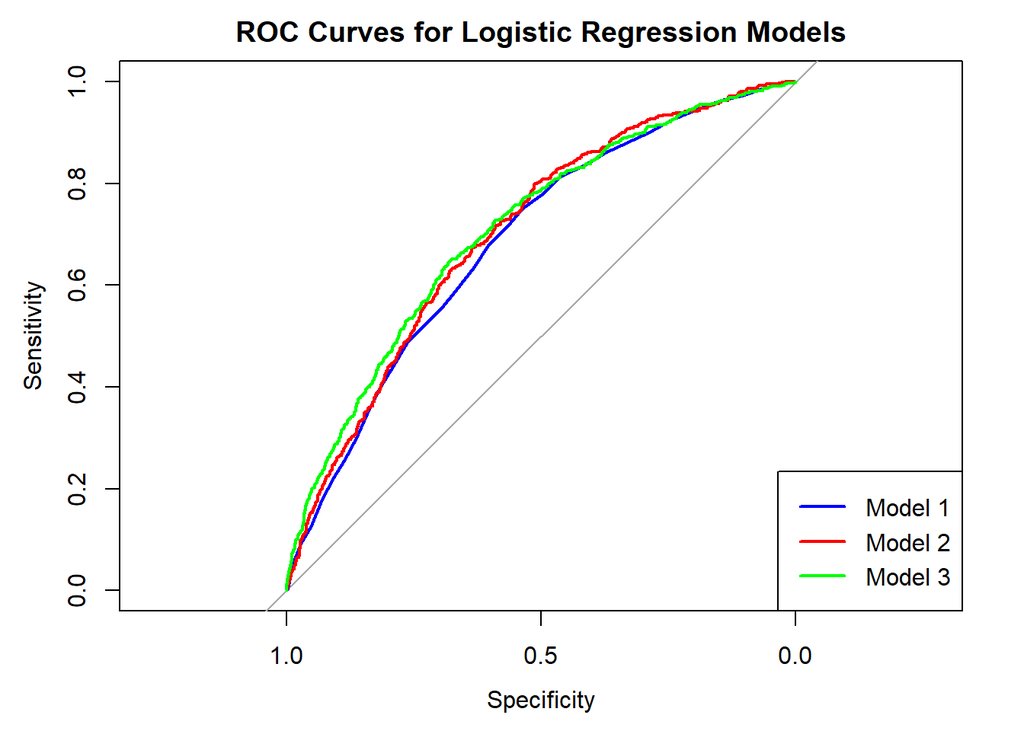

```r
# Plot ROC Curves for all Models
roc_model_1 <- roc(HeartHealth_clean$TenYearCHD, predict(model_1, type = "response"))
roc_model_2 <- roc(HeartHealth_clean$TenYearCHD, predict(model_2, type = "response"))
roc_model_3 <- roc(HeartHealth_clean$TenYearCHD, predict(model_3, type = "response"))

plot(roc_model_1, col = "blue", main = "ROC Curves for Logistic Regression Models")
plot(roc_model_2, add = TRUE, col = "red")
plot(roc_model_3, add = TRUE, col = "green")
legend("bottomright", legend = c("Model 1", "Model 2", "Model 3"), col = c("blue", "red", "green"), lwd = 2)
```

```r
# Determine the Best Model Based on AUC
auc_values <- c(auc(roc_model_1), auc(roc_model_2), auc(roc_model_3))
names(auc_values) <- c("Model 1", "Model 2", "Model 3")
best_model <- names(which.max(auc_values))
print(paste("The best model is:", best_model))
```

```
[1] "The best model is: Model 3"
```

```r
# Cut-off Probability Search for Best Model
best_model_glm <- switch(best_model, "Model 1" = model_1, "Model 2" = model_2, "Model 3" = model_3)
thresholds <- seq(0.1, 0.9, by = 0.1)
best_threshold <- 0
best_accuracy <- 0

for (t in thresholds) {
  predicted <- ifelse(predict(best_model_glm, type = "response") > t, "Yes", "No")
  confusion <- table(predicted, HeartHealth_clean$TenYearCHD)
  accuracy <- sum(diag(confusion)) / sum(confusion)
  if (accuracy > best_accuracy) {
    best_accuracy <- accuracy
    best_threshold <- t
  }
}

print(paste("The optimal cut-off probability is:", best_threshold))
```

```
[1] "The optimal cut-off probability is: 0.5"
```

## 5.4 Results and Conclusion

Based on the model with the highest AUC, **Model 3** was identified as the best logistic regression model. The optimal cut-off probability for predicting **TenYearCHD** was determined to be 0.5.

**Interpretation**:

**Age**: The coefficient for **age** suggests that as age increases, the probability of experiencing a CHD event within ten years also increases. This aligns with known cardiovascular risk factors, where older individuals are at greater risk.

**Glucose**: The coefficient for **glucose** suggests that higher glucose levels are linked to an elevated risk of CHD, reflecting the impact of elevated blood sugar on cardiovascular health.

**Prevalent Hypertension**: The coefficient for **prevalentHyp** shows that individuals with hypertension are more likely to develop CHD, which is consistent with hypertension being a major risk factor for cardiovascular disease.

# 6 Summary and Discussion

This project involved building predictive models to assess the ten-year risk of coronary heart disease (CHD) using data from the Framingham Heart Study. We performed exploratory data analysis (EDA), feature engineering, linear regression, and logistic regression to identify key predictors and create effective models.

## 6.2 Strengths and Weaknesses

**Strengths**:

- The dataset from the Framingham Heart Study is well-known and comprehensive, allowing for a robust analysis of cardiovascular health predictors.
- Cross-validation was used to avoid overfitting and ensure model generalizability.
- Both linear and logistic regression models were used to address different types of questions, providing a well-rounded analysis.

**Weaknesses**:

- The dataset had some missing values that required removal, which may have led to a reduction in sample size and potential loss of information.
- There may be potential biases due to the population being primarily from a single study cohort, which could affect the generalizability of the findings to broader populations.
- Logistic regression assumes linear relationships between predictors and the log-odds of the outcome, which may oversimplify complex interactions.

## 6.3 Potential Improvements

Future analyses could benefit from incorporating more sophisticated models such as decision trees or ensemble methods to capture potential non-linear relationships and interactions between variables.

**Feature engineering** could be enhanced by using domain knowledge to create more complex interaction features that may better capture the combined effects of multiple risk factors.

To address the **imbalance** in the **TenYearCHD** outcome variable, resampling techniques such as **SMOTE** could be used to improve model performance.